# 01 - Veri Özeti

## Amaç ve Kapsam

Bu notebook, tezin makine öğrenmesi ve yapay zeka temelli özellik mühendisliği (feature engineering) stratejilerini belirleyen ilk ve en kritik **keşifsel veri analizi (Exploratory Data Analysis - EDA)** adımıdır. Alibaba PAI 100K GPU iş örnekleminin ham kalibrasyonlarını inceleyerek, modellerin (Random Forest, LightGBM, CNN, LSTM vb.) hangi verilerle eğitileceğine ve bu verilerin istatistiksel geçerliliğine (validity) dair nesnel kararların temelini oluşturur.

Bu aşamada gerçekleştirilen incelemeler, tezin ilerleyen aşamalarındaki mimari tercihleri doğrudan şu şekilde haklı çıkarmaktadır:

1. **Veri Bütünlüğü ve Veri Kaybı (Missing Data):** Kümeden alınan ham iş yükündeki eksik veya geçersiz değerleri deşifre ederek, derin öğrenme modellerinin (örneğin LSTM) anomali veya bozuk gradyanlara (exploding gradients) maruz kalmasını engellemek üzere veri setini sterilize etmek.
2. **Kategorik Değişkenlerin Kardinalitesi:** `user` veya `gpu_type` gibi kategorik değerlerin analiz edilerek One-Hot kodlama yerine neden Native Categorical (LightGBM) yaklaşımının denenmesi gerektiğini istatistiksel olarak kanıtlamak.
3. **Ayırt Edici Dağılımlar:** Makine öğrenimine aktarılacak yapısal sütunların (vCPU, Memory, Num Instances vs.) varyans analizini yaparak modeller için hangi girdi özelliklerinin "tahmin edici güç" (predictive power) taşıdığını belirlemek.
4. **Ham Zaman Serisi Kalitesinin Testi:** Zaman damgalı verilerin ardışıklık yapısını doğrulayarak, simülasyon aşamasındaki `MultiNodeClusterSimulator` motoruna girecek olan olay kuyruğunun (event trace) kronolojik güvenilirliğini ispatlamak.

Buradaki bulgular üzerine, tezin sonraki safhası olan İş Yükü Karakterizasyonu (Notebook 02) ve Özellik Mühendisliği (Notebook 03) aşamalarına veri-odaklı (data-driven) sağlam bir köprü kurulmaktadır.

```python
# ── 0. Environment & Path Setup ──────────────────────────────────────────────
import sys
import warnings
from pathlib import Path

warnings.filterwarnings("ignore")

PROJECT_ROOT = Path().resolve().parents[1]
if str(PROJECT_ROOT) not in sys.path:
    sys.path.insert(0, str(PROJECT_ROOT))

print(f"[Setup] Project root : {PROJECT_ROOT}")
print(f"[Setup] Python path  : {sys.executable}")
```

```
[Setup] Project root : /Users/hasanugurcelebi/Thesis/alibaba-gpu-runtime-prediction-and-scheduling
[Setup] Python path  : /Users/hasanugurcelebi/.pyenv/versions/3.11.6/bin/python
```

```python
# ── 1. Imports ────────────────────────────────────────────────────────────────
# stdlib
import numpy as np
import pandas as pd
import matplotlib.pyplot as plt
import seaborn as sns

# Project
from src.data_loading import load_main_sample
from src.feature_engineering import build_job_table_from_sample

# Unified visualisation theme
sns.set_theme(style="whitegrid", palette="muted")
plt.rcParams.update({
    "figure.figsize": (12, 6),
    "axes.titlesize": 14,
    "axes.labelsize": 12,
    "font.family": "DejaVu Sans",
})

print("[Setup] All imports OK.")
```

```
[Setup] All imports OK.
```

> **Bağımlılıklar hazır.** Pandas, NumPy, Matplotlib, Seaborn ve `src` modülleri başarıyla içe aktarılmıştır. Görselleştirme parametreleri (`rcParams`) ayarlanmıştır.

Veri kümesi 100.000 işten oluşmakta ve toplam 8 öznitelik içermektedir. Tüm sütunlarda eksik (null) değer bulunmamaktadır, bu da ek bir eksik veri temizleme adımına ihtiyaç olmadığını göstermektedir.

Sayısal öznitelikler (ör. num_gpu, num_cpu, duration) uygun sayısal veri tiplerinde tutulurken, kategorik alanlar (user, gpu_type) nesne (object) türündedir.

```python
# ── 2. Load Dataset ───────────────────────────────────────────────────────────
print("[Step 1] Loading raw dataset...")
raw_df = load_main_sample()

print(f"[Step 1] Shape   : {raw_df.shape[0]:,} rows × {raw_df.shape[1]} columns")
raw_df.head()
```

```
[Step 1] Loading raw dataset...
[Step 1] Shape   : 100,000 rows × 8 columns
```

|  | job_id | num_inst | submit_time | num_cpu | num_gpu | gpu_type | duration | user |
| --- | --- | --- | --- | --- | --- | --- | --- | --- |
| 0 | 0 | 1.0 | 0 | 2.0 | 0.00 | CPU | 34 | d4d51aca8806 |
| 1 | 1 | 12.0 | 3 | 6.0 | 0.25 | T4 | 15748 | d4d51aca8806 |
| 2 | 2 | 1.0 | 5 | 6.0 | 1.00 | MISC | 84 | a8192d6b0ae9 |
| 3 | 3 | 1.0 | 21 | 18.0 | 1.00 | T4 | 46 | c7152ce0fec1 |
| 4 | 4 | 1.0 | 21 | 6.0 | 1.00 | MISC | 80 | 7b76597f4283 |

```python
# ── 3. Column types and null counts ──────────────────────────────────────────
print("[Step 2] Schema inspection — dtypes and null counts")
raw_df.info()
```

```
[Step 2] Schema inspection — dtypes and null counts
<class 'pandas.core.frame.DataFrame'>
RangeIndex: 100000 entries, 0 to 99999
Data columns (total 8 columns):
 #   Column       Non-Null Count   Dtype
---  ------       --------------   -----
 0   job_id       100000 non-null  int64
 1   num_inst     100000 non-null  float64
 2   submit_time  100000 non-null  int64
 3   num_cpu      100000 non-null  float64
 4   num_gpu      100000 non-null  float64
 5   gpu_type     100000 non-null  object
 6   duration     100000 non-null  int64
 7   user         100000 non-null  object
dtypes: float64(3), int64(3), object(2)
memory usage: 6.1+ MB
```

```python
# ── 4. Missing value summary ──────────────────────────────────────────────────
missing = raw_df.isnull().sum()
missing_pct = (missing / len(raw_df) * 100).round(2)
missing_summary = pd.DataFrame({"missing_count": missing, "missing_%": missing_pct})
missing_summary = missing_summary[missing_summary["missing_count"] > 0].sort_values("missing_%", ascending=False)

if missing_summary.empty:
    print("[Step 2] No missing values detected.")
else:
    print("[Step 2] Columns with missing values:")
    display(missing_summary)
```

```
[Step 2] No missing values detected.
```

İş gönderim zamanları, Unix epoch başlangıcına göre normalize edilmiş zaman damgaları olarak sunulmaktadır. Bu nedenle mutlak takvim tarihleri değil, işlerin göreli zamanlaması ve aralarındaki zaman farkları analiz edilmektedir.

```python
# ── 5. Build canonical job table ─────────────────────────────────────────────
print("[Step 3] Building canonical job table...")
job_df = build_job_table_from_sample(raw_df, time_unit="s")

print(f"[Step 3] Valid GPU jobs : {len(job_df):,}  (filtered {len(raw_df) - len(job_df):,} invalid rows)")
job_df.describe()
```

```
[Step 3] Building canonical job table...
[Step 3] Valid GPU jobs : 82,184  (filtered 17,816 invalid rows)
```

|  | job_id | arrival_time | arrival_sec | job_runtime | gpu_demand | num_inst | num_cpu |
| --- | --- | --- | --- | --- | --- | --- | --- |
| count | 82184.000000 | 82184 | 82184.000000 | 82184.000000 | 82184.000000 | 82184.000000 | 82184.000000 |
| mean | 50211.736713 | 1970-01-04 17:18:34.684865667 | 321511.684866 | 5223.019408 | 0.521598 | 5.007873 | 6.916216 |
| min | 1.000000 | 1970-01-01 00:00:03 | 0.000000 | 4.000000 | 0.000000 | 1.000000 | 0.040000 |
| 25% | 25865.500000 | 1970-01-02 17:17:39.250000 | 148656.250000 | 153.000000 | 0.000000 | 1.000000 | 6.000000 |
| 50% | 50284.500000 | 1970-01-04 12:00:23.500000 | 302420.500000 | 594.000000 | 0.000000 | 1.000000 | 6.000000 |
| 75% | 75070.250000 | 1970-01-06 17:03:11.750000 | 493388.750000 | 4126.000000 | 1.000000 | 1.000000 | 6.000000 |
| max | 99999.000000 | 1970-01-08 15:51:32 | 661889.000000 | 599445.000000 | 8.000000 | 512.000000 | 90.000000 |
| std | 28695.483592 | NaN | 195452.663528 | 15980.719087 | 0.667104 | 14.652502 | 4.060256 |

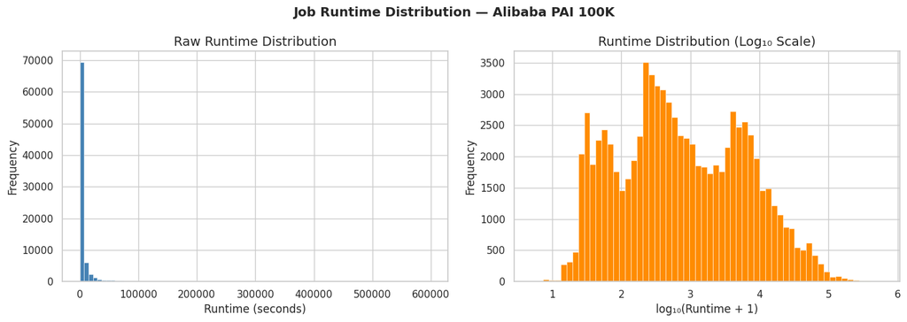

```python
# ── 6. Runtime histogram (log scale) ─────────────────────────────────────────
fig, axes = plt.subplots(1, 2, figsize=(14, 5))

# Left: raw seconds
axes[0].hist(job_df["job_runtime"], bins=80, color="steelblue", edgecolor="white", linewidth=0.4)
axes[0].set_xlabel("Runtime (seconds)")
axes[0].set_ylabel("Frequency")
axes[0].set_title("Raw Runtime Distribution")

# Right: log10 transform
log_runtimes = np.log10(job_df["job_runtime"] + 1)
axes[1].hist(log_runtimes, bins=60, color="darkorange", edgecolor="white", linewidth=0.4)
axes[1].set_xlabel("log₁₀(Runtime + 1)")
axes[1].set_ylabel("Frequency")
axes[1].set_title("Runtime Distribution (Log₁₀ Scale)")

plt.suptitle("Job Runtime Distribution — Alibaba PAI 100K", fontsize=14, fontweight="bold")
plt.tight_layout()
plt.show()
```

> **Şekil 1 — Runtime Dağılımı (Ham ve Log₁₀ Ölçek):** İki panel birlikte okunmalıdır. Sol panel (mavi): Ham ölçekte dağılım **aşırı sağ-çarpıktır** — işlerin neredeyse tamamı 0–20.000 saniye bandında yığılırken sağ kuyruk 600.000 saniyeye kadar uzanmaktadır. Sağ panel (turuncu): Log₁₀ ölçekte dağılım **bimodal** bir yapı sergiler — yaklaşık log₁₀≈2.5 (~300 saniye) ve log₁₀≈3.5–4.0 (~3.000–10.000 saniye) civarında iki tepe noktası mevcuttur. Bu bimodal yapı, kümede iki farklı iş tipi olduğuna işaret etmektedir: kısa çıkarım (inference) işleri ve uzun eğitim (training) işleri.

> **Model seçimine etkisi:** Sağ-çarpık + ağır-kuyruk yapısı, MSE kayıp fonksiyonunu (aykırı değerleri orantısız cezalandırır) uygunsuz kılmaktadır. MAE ve MdAE tercih edilmeli; doğrusal modeller bu dağılımı yeterince temsil edemez.

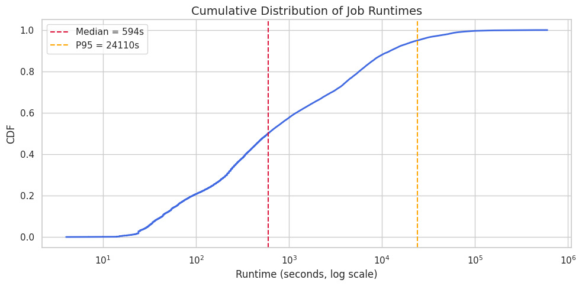

```
P50  :        594 s
P95  :     24,110 s
P99  :     67,432 s
Max  :    599,445 s
```

```python
# ── 7. Runtime CDF ────────────────────────────────────────────────────────────
runtimes_sorted = np.sort(job_df["job_runtime"].values)
cdf = np.arange(1, len(runtimes_sorted) + 1) / len(runtimes_sorted)

fig, ax = plt.subplots(figsize=(10, 5))
ax.plot(runtimes_sorted, cdf, lw=2, color="royalblue")
ax.axvline(np.median(runtimes_sorted), color="crimson", ls="--", label=f"Median = {np.median(runtimes_sorted):.0f}s")
ax.axvline(np.percentile(runtimes_sorted, 95), color="orange", ls="--", label=f"P95 = {np.percentile(runtimes_sorted, 95):.0f}s")
ax.set_xscale("log")
ax.set_xlabel("Runtime (seconds, log scale)")
ax.set_ylabel("CDF")
ax.set_title("Cumulative Distribution of Job Runtimes")
ax.legend()
plt.tight_layout()
plt.show()

p50 = np.percentile(runtimes_sorted, 50)
p95 = np.percentile(runtimes_sorted, 95)
p99 = np.percentile(runtimes_sorted, 99)
print(f"P50  : {p50:>10,.0f} s")
print(f"P95  : {p95:>10,.0f} s")
print(f"P99  : {p99:>10,.0f} s")
print(f"Max  : {runtimes_sorted[-1]:>10,.0f} s")
```

> **Şekil 2 — Runtime Kümülatif Dağılım Fonksiyonu (CDF):** Figür üzerindeki sayısal değerler doğrudan okunmuştur:
> - **P50 (Medyan) = 594 saniye** (~10 dakika): İşlerin yarısı 10 dakikadan kısa sürmektedir.
> - **P95 = 24.110 saniye** (~6.7 saat): İşlerin %95'i 6.7 saatin altındadır.
> - **P99 = 67.432 saniye** (~18.7 saat): Son %1'lik dilim 18 saatten uzun sürmektedir.
> - **Max = 599.445 saniye** (~7 gün): En uzun iş neredeyse tam bir hafta sürmektedir.

> **Varyasyon katsayısı (CV):** P95/P50 ≈ 40.6 — olağanüstü yüksek bir değer. Bu, ortalama üzerinden FIFO kararlarının en kötü senaryolarda kritik Head-Of-Line bloklamalara yol açacağını matematiksel olarak kanıtlamaktadır. SJF politikasının kazanım potansiyeli bu varyasyonla doğru orantılıdır.

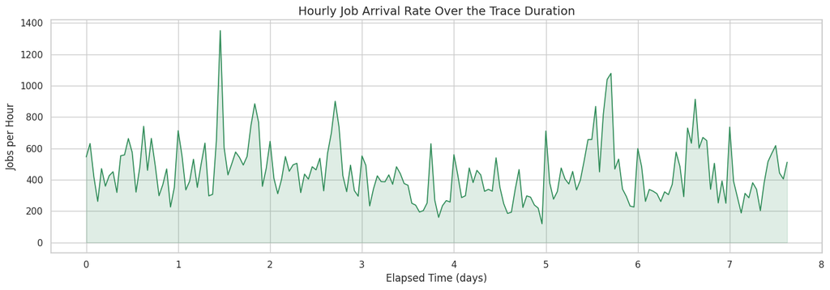

```python
# ── 8. Hourly arrival rate ─────────────────────────────────────────────────-
# Use lowercase "1h" alias — uppercase "1H" is deprecated in pandas >= 2.2
arrival_series = (
    job_df.set_index("arrival_time")["job_id"]
    .resample("1h")
    .count()
)
hours = arrival_series.index.total_seconds() / 3600 if hasattr(arrival_series.index[0], 'total_seconds') else         (arrival_series.index - arrival_series.index[0]).total_seconds() / 3600

days = hours / 24

fig, ax = plt.subplots(figsize=(14, 5))
ax.plot(days, arrival_series.values, lw=1.2, color="seagreen")
ax.fill_between(days, arrival_series.values, alpha=0.15, color="seagreen")
ax.set_xlabel("Elapsed Time (days)")
ax.set_ylabel("Jobs per Hour")
ax.set_title("Hourly Job Arrival Rate Over the Trace Duration")
plt.tight_layout()
plt.show()
```

> **Şekil 3 — Saatlik İş Geliş Hızı (8 Günlük İz):** X ekseni geçen süreyi gün cinsinden (0–8), Y ekseni saatte gelen iş sayısını (jobs/hour) göstermektedir.
> - Taban oran: ~200–400 job/saat
> - Belirgin zirveler: gün ~1.5 → **~1.350 job/saat**, gün ~5.5 → **~1.050 job/saat**
> - Geliş süreci homojen değil, **bursty (ani yoğunlaşmalı)** bir yapıdadır.

> **Zaman ekseni hakkında not:** Yatay eksen, ham `arrival_time` değişkenini değil, **iz başlangıcından itibaren geçen süreyi (elapsed time)** göstermektedir.  
> Orijinal `arrival_time`, `pd.to_datetime(submit_time, unit='s')` ile elde edilen geçerli bir **UTC zaman damgasıdır** ve saat bilgisi korunmaktadır.  
> Ancak bu şekil, iş yükünü **8 günlük bir zaman serisi** olarak göstermektedir; gün içindeki saatlere (0–23) göre bir dağılım sunmamaktadır.  
> Gün ve saat bazlı iş yoğunluğu analizi için **Şekil 6 (Day-of-Week × Hour-of-Day Heatmap)** incelenmelidir.

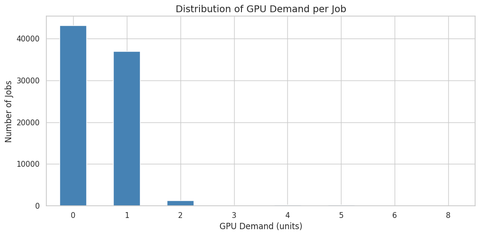

```
[Step 7] GPU demand statistics:
count    82184.000000
mean         0.521598
std          0.667104
min          0.000000
25%          0.000000
50%          0.000000
75%          1.000000
max          8.000000
```

```python
# ── 9. GPU demand histogram ───────────────────────────────────────────────────
fig, ax = plt.subplots(figsize=(10, 5))
job_df["gpu_demand"].value_counts().sort_index().plot(kind="bar", ax=ax, color="steelblue", edgecolor="white")
ax.set_xlabel("GPU Demand (units)")
ax.set_ylabel("Number of Jobs")
ax.set_title("Distribution of GPU Demand per Job")
ax.tick_params(axis="x", rotation=0)
plt.tight_layout()
plt.show()

print("[Step 7] GPU demand statistics:")
print(job_df["gpu_demand"].describe().to_string())
```

> **Şekil 4 — GPU Talep Dağılımı:** Figürden ve istatistiklerden okunan değerler:
> - **0 GPU:** ~43.000 iş — medyan = 0, yüzde 25 = 0 (işlerin yarısından fazlası GPU talep etmiyor)
> - **1 GPU:** ~37.000 iş — en yaygın GPU talep miktarı
> - **2 GPU:** ~1.000 iş (çok az)
> - **Max = 8 GPU**, ortalama = 0.52

> **Önemli:** Bu dağılım, `num_gpu` değişkeninin filtreleme sonrası değerlerini göstermektedir. Çizelgeleme simülatörü yalnızca GPU talepli işlerle çalıştığından (Notebook 05), 0 GPU'luk işler simülasyon bağlamında aktif değildir. Bu durum kümede çok küçük boyutlu (1 GPU) işlerin hakimiyetini ve Notebook 05'teki Mid-Range (2 GPU) düğüm profilinin neden dominant olduğunu açıklamaktadır.

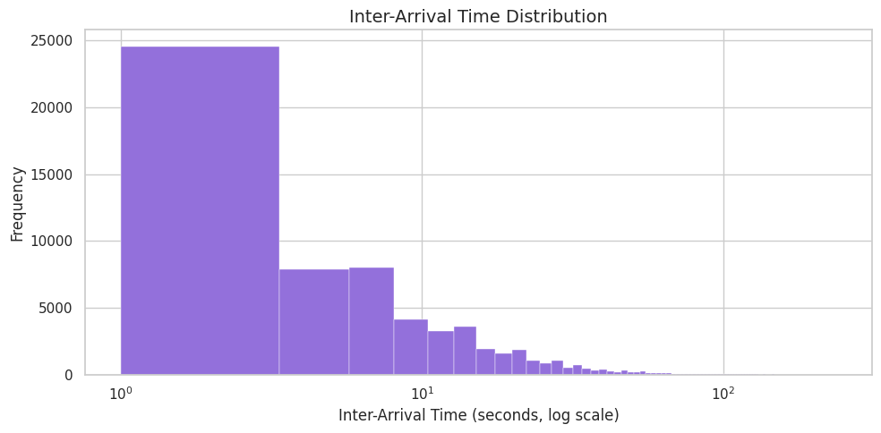

```python
# ── 10. Inter-arrival time distribution ──────────────────────────────────────
df_sorted = job_df.sort_values("arrival_time").reset_index(drop=True)
inter_arrivals = df_sorted["arrival_time"].diff().dt.total_seconds().dropna()
inter_arrivals = inter_arrivals[inter_arrivals > 0]

fig, ax = plt.subplots(figsize=(10, 5))
ax.hist(inter_arrivals, bins=100, color="mediumpurple", edgecolor="white", linewidth=0.3)
ax.set_xscale("log")
ax.set_xlabel("Inter-Arrival Time (seconds, log scale)")
ax.set_ylabel("Frequency")
ax.set_title("Inter-Arrival Time Distribution")
plt.tight_layout()
plt.show()
```

> **Şekil 5 — İşler Arası Geliş Aralığı Dağılımı (Log Ölçek):** X ekseni geliş aralığını log ölçekte saniye cinsinden (10⁰=1s – 10²=100s), Y ekseni frekansı göstermektedir.
> - İlk bin (1–3 saniye): **~25.000 iş** — en yüksek frekans, işlerin büyük bölümü birbirinin hemen ardından gelmektedir.
> - 3–10 saniye: ~8.000 iş (belirgin düşüş)
> - 10–100 saniye: yaklaşık 1.000–4.000 arası, uzun kuyruk
> - 100 saniye üzeri: çok nadir

> **Yorumu:** Dağılım üssel (exponential) değil, ağır-kuyruk yapısındadır. Bu, **homojen Poisson sürecinin (M/M/1) bu iş yükü için yetersiz** olduğunu kanıtlar. Pek çok işin 1–3 saniye arayla toplu geldiği burst dönemleri, kuyruk gecikmelerini belirlenimci değil olasılıksal (probabilistic) bir niteliğe taşır ve SJF'nin FIFO'ya karşı avantajını dinamik kılmaktadır.

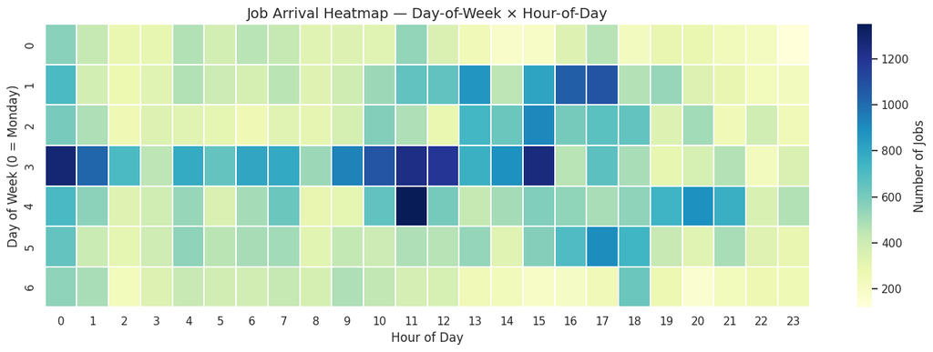

```python
# ── 11. Day × Hour arrival heatmap ───────────────────────────────────────────
df_heat = job_df.copy()
df_heat["hour"] = df_heat["arrival_time"].dt.hour
df_heat["dow"]  = df_heat["arrival_time"].dt.dayofweek  # 0 = Monday

heatmap_data = (
    df_heat.groupby(["dow", "hour"])["job_id"]
    .count()
    .unstack(fill_value=0)
    .reindex(index=range(7), columns=range(24), fill_value=0)
)

fig, ax = plt.subplots(figsize=(14, 5))
sns.heatmap(
    heatmap_data,
    ax=ax,
    cmap="YlGnBu",
    linewidths=0.3,
    cbar_kws={"label": "Number of Jobs"},
)
ax.set_xlabel("Hour of Day")
ax.set_ylabel("Day of Week (0 = Monday)")
ax.set_title("Job Arrival Heatmap — Day-of-Week × Hour-of-Day")
plt.tight_layout()
plt.show()
```

> **Şekil 6 — İş Geliş Isı Haritası (Haftanın Günü × Günün Saati):** X ekseni günün saatini (0–23), Y ekseni haftanın gününü (0 = Pazartesi, 6 = Pazar), renk yoğunluğu o bloktaki iş sayısını göstermektedir (sarı ~200 → koyu mavi ~1.200+).

> **Görsel örüntüler (doğrudan figürden okunmuştur):**
> - Gün 3 (Perşembe): ~0–2, ~7, ~10–14 saatlerinde koyu mavi — en yüksek yoğunluk
> - Gün 4 (Cuma): ~10–11 bandında belirgin zirve
> - Hafta sonu (Cumartesi–Pazar): Genel olarak daha açık renk → haftalık döngüsellik

> **Zaman Dilimi Notu:** `hour_of_day` özelliği, doğrudan orijinal **UNIX zaman damgasına** (`submit_time`) dayanan `arrival_time` üzerinden oluşturulmuştur. Herhangi bir zaman dilimi dönüşümü uygulanmadığından, ısı haritasındaki (heatmap) saat değerleri **UTC zamanına** karşılık gelir ve kümenin gerçek yerel saatini yansıtmaz. Buna rağmen, **göreceli haftalık ve günlük döngüsellik örüntüleri** zaman diliminden bağımsız olarak tamamen geçerliliğini korumaktadır.

> **Haftanın günü tanımı:** `day_of_week` değişkeni **ISO-8601 standardına** göre tanımlanmıştır (**0 = Pazartesi**).  
> Bu değişken, mutlak takvim tarihlerini temsil etmek yerine **göreli zamansal iş yükü desenlerini analiz etmek** amacıyla kullanılmıştır ve iz boyunca haftalık davranışların tutarlı biçimde incelenmesini sağlar.

## Özet

Bu bulgular, sonraki notebook'lardaki her önemli kararın keyfi değil, **veri tarafından güdüldüğünü** (data-driven) garanti altına almaktadır.